# Correspondence Analysis Presentation with R

Randi Eka Sanjaya  
06/11/2022

### Reference:

- https://cran.r-project.org/web/packages/FactoMineR/FactoMineR.pdf
- http://www.sthda.com/english/articles/31-principal-component-methods-in-r-practical-guide/113-ca-correspondence-analysis-in-r-essentials/
- https://www.geeksforgeeks.org/contingency-tables-in-r-programming/

### 1. Install Libraries

```r
#install.packages("FactoMineR")
#install.packages("factoextra")
library(FactoMineR) # For CA analysis
library(factoextra) # For CA visualization
```

### 2. Load Dataset

```r
data(housetasks)
housetasks
```

```
           Wife Alternating Husband Jointly
Laundry     156          14       2       4
Main_meal   124          20       5       4
Dinner       77          11       7      13
Breakfeast   82          36      15       7
Tidying      53          11       1      57
Dishes       32          24       4      53
Shopping     33          23       9      55
Official     12          46      23      15
Driving      10          51      75       3
Finances     13          13      21      66
Insurance     8           1      53      77
Repairs       0           3     160       2
Holidays      0           1       6     153
```

### 3. Create Balloon Plot

This is graphical matrix where each cell contains a dot whose size reflects the relative magnitude of the corresponding component

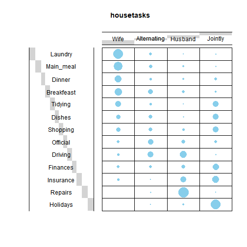

```r
#install.packages("gplots")
library(gplots)
# 1. Convert tht data as a table
dt = as.table(as.matrix(housetasks))
# 2. Graph
balloonplot(t(dt), main = "housetasks", xlab="", ylab="",
            label = FALSE, show.margins=FALSE)
```

### 4. Chi-Square Test

Reference:

- https://www.youtube.com/watch?v=xcbJSFr_A5g

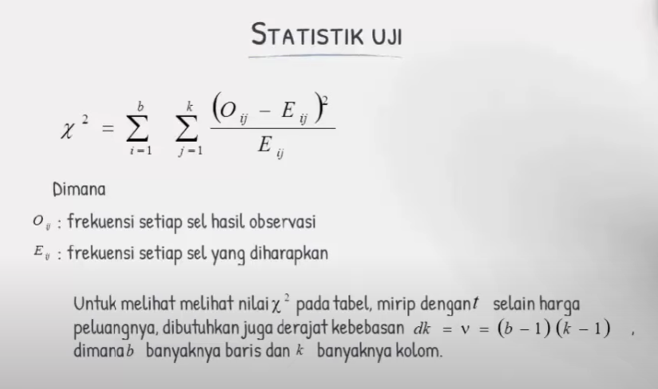

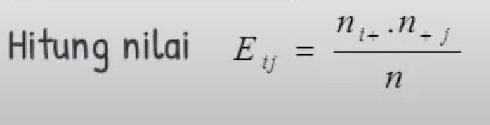

### Lanjutan

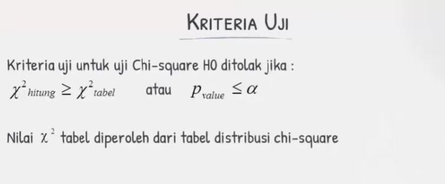

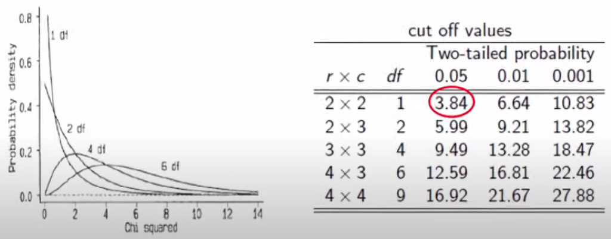

Use Chi-square test to evaluate whether there is a significant dependence between row and column categories:

```r
chisq = chisq.test(dt)
chisq
```

```
    Pearson's Chi-squared test

data:  dt
X-squared = 1944.5, df = 36, p-value < 2.2e-16
```

### 5. Symmetric Biplot

In symmetric biplot, the goal is to do correspondence analysis which includes columns and rows that being represented in the same space using principal coordinates. The coordinates represent the row and column profile. In symmetric biplot, only the distance between row points or the distance between column points can really be interpreted.

### 5a. Compute CA

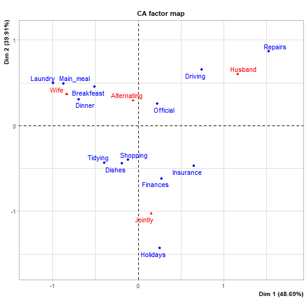

```r
vis_ca = CA(dt, ncp = 5, graph = TRUE)
```

```r
vis_ca
```

```
**Results of the Correspondence Analysis (CA)**
The row variable has  13  categories; the column variable has 4 categories
The chi square of independence between the two variables is equal to 1944.456 (p-value =  0 ).
*The results are available in the following objects:

   name              description
1  "$eig"            "eigenvalues"
2  "$col"            "results for the columns"
3  "$col$coord"      "coord. for the columns"
4  "$col$cos2"       "cos2 for the columns"
5  "$col$contrib"    "contributions of the columns"
6  "$row"            "results for the rows"
7  "$row$coord"      "coord. for the rows"
8  "$row$cos2"       "cos2 for the rows"
9  "$row$contrib"    "contributions of the rows"
10 "$call"           "summary called parameters"
11 "$call$marge.col" "weights of the columns"
12 "$call$marge.row" "weights of the rows"
```

```r
print(vis_ca)
```

```
**Results of the Correspondence Analysis (CA)**
The row variable has  13  categories; the column variable has 4 categories
The chi square of independence between the two variables is equal to 1944.456 (p-value =  0 ).
*The results are available in the following objects:

   name              description
1  "$eig"            "eigenvalues"
2  "$col"            "results for the columns"
3  "$col$coord"      "coord. for the columns"
4  "$col$cos2"       "cos2 for the columns"
5  "$col$contrib"    "contributions of the columns"
6  "$row"            "results for the rows"
7  "$row$coord"      "coord. for the rows"
8  "$row$cos2"       "cos2 for the rows"
9  "$row$contrib"    "contributions of the rows"
10 "$call"           "summary called parameters"
11 "$call$marge.col" "weights of the columns"
12 "$call$marge.row" "weights of the rows"
```

### 5b. Extract the eigenvalues/variances retained by each dimension (axis)

```r
get_eigenvalue(vis_ca)
```

```
      eigenvalue variance.percent cumulative.variance.percent
Dim.1  0.5428893         48.69222                    48.69222
Dim.2  0.4450028         39.91269                    88.60491
Dim.3  0.1270484         11.39509                   100.00000
```

### 5c. Visualize the eigenvalues

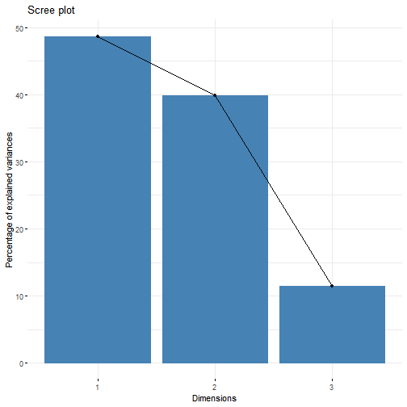

```r
fviz_eig(vis_ca)
```

### 5d. Extract the results for rows and columns, respectively

```r
get_ca_row(vis_ca)
```

```
Correspondence Analysis - Results for rows
 ===================================================
  Name       Description
1 "$coord"   "Coordinates for the rows"
2 "$cos2"    "Cos2 for the rows"
3 "$contrib" "contributions of the rows"
4 "$inertia" "Inertia of the rows"
```

```r
get_ca_col(vis_ca)
```

```
Correspondence Analysis - Results for columns
 ===================================================
  Name       Description
1 "$coord"   "Coordinates for the columns"
2 "$cos2"    "Cos2 for the columns"
3 "$contrib" "contributions of the columns"
4 "$inertia" "Inertia of the columns"
```

### 5e. Visualize the results for rows and columns

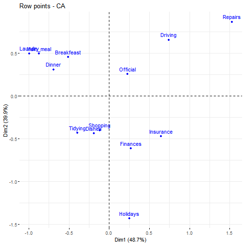

```r
fviz_ca_row(vis_ca)
```

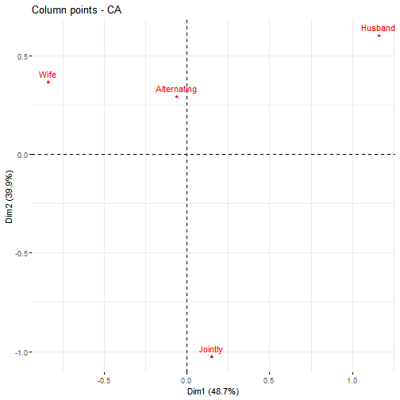

```r
fviz_ca_col(vis_ca)
```

### 5f. Make a biplot of rows and columns

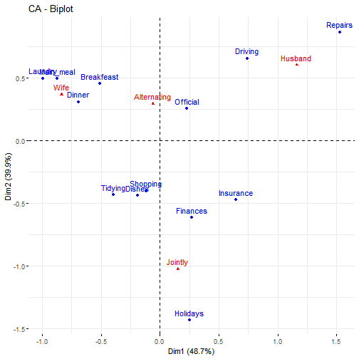

```r
fviz_ca_biplot(vis_ca)
```

### 5g. Statistical Significance

Examining the association between row and column variables

```r
# Chi-sqiare statistics
chi2 = 1944.5
# Degree of Freedom
df = (nrow(housetasks) -1)*(ncol(housetasks)-1)
# P-value
pval = pchisq(chi2, df=df, lower.tail=FALSE)
pval
```

```
[1] 0
```

### 5f. Eigenvalues / Variances

Examine the eigenvalues to determine the number of axis to be considered

```r
library("factoextra")
eig.val = get_eigenvalue(vis_ca)
eig.val
```

```
      eigenvalue variance.percent cumulative.variance.percent
Dim.1  0.5428893         48.69222                    48.69222
Dim.2  0.4450028         39.91269                    88.60491
Dim.3  0.1270484         11.39509                   100.00000
```

### 5g. Scree Plot

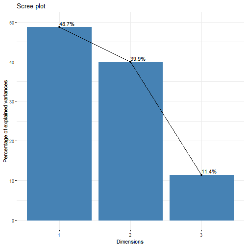

```r
fviz_screeplot(vis_ca, addlabels = TRUE, ylim = c(0,50))
```

### 5h. Calculate an average eigenvalue

This to determine which the axis should be kept in the solution.

If the data were random, the expected value of the eigenvalue for each axis would be:

```r
1/(nrow(housetasks)-1)
```

```
[1] 0.08333333
```

Likewise, the average axis should account for:

```r
1/(ncol(housetasks)-1)
```

```
[1] 0.3333333
```

In terms of the 4 columns

Any axis with a contribution larger than the maximum of these two percentages should be considered as important and included in the solution for the interpretation of the data.

### 5i. Draw screeplot with red dashed line specifying the average eigenvalue:

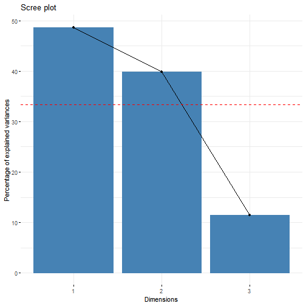

```r
fviz_screeplot(vis_ca)+
  geom_hline(yintercept=33.33, linetype=2, color="red")
```

Since the average of eigenvalue around 33.3%, only choose the dimention that explain variances above 33.33, which are dimension 1 and 2

### 5j. Draw biplot of rows and columns variables with symetric plot

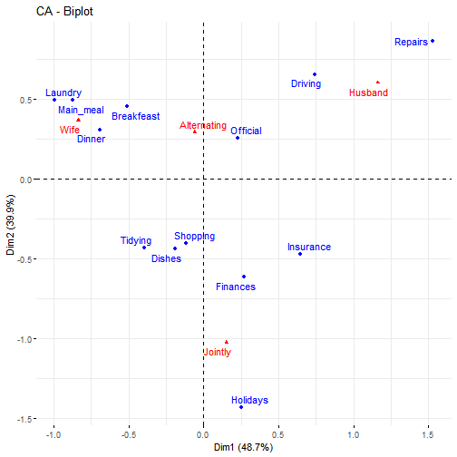

```r
fviz_ca_biplot(vis_ca, repel=TRUE)
```

rows are in blue point, and columns are in red point. The distance between any row points or column point gives a measure of their similarity (or dissimilarity). Row points with similar profile are closed on the factor map. The same holds true for column points

### Notes:

- Symetric plot represents the row and column profiles simultaneously in a common space. In this case, only the distance between row points or the distance between column points can be really interpreted.
- The distance between any row and column items is not meaningful! You can only make a general statements about the observed pattern.
- In order to interpret the distance between column and row points, the column profiles must be presented in row space or vice-versa. This type of map is called asymmetric biplot

### 5k. Graph of Row Variables

Determine which row variables contribute the most in the definition of the different dimensions retained in the model.

```r
# Return a list containing the coordinates, the cos2, the contribution and the inertia of row variables:
row = get_ca_row(vis_ca)
row
```

```
Correspondence Analysis - Results for rows
 ===================================================
  Name       Description
1 "$coord"   "Coordinates for the rows"
2 "$cos2"    "Cos2 for the rows"
3 "$contrib" "contributions of the rows"
4 "$inertia" "Inertia of the rows"
```

### 5l. Coordinates

```r
# Coordinates of each row point in each dimention (1,2, and 3). Used to create the scatter plot
head(row$coord)
```

```
                Dim 1      Dim 2       Dim 3
Laundry    -0.9918368  0.4953220 -0.31672897
Main_meal  -0.8755855  0.4901092 -0.16406487
Dinner     -0.6925740  0.3081043 -0.20741377
Breakfeast -0.5086002  0.4528038  0.22040453
Tidying    -0.3938084 -0.4343444 -0.09421375
Dishes     -0.1889641 -0.4419662  0.26694926
```

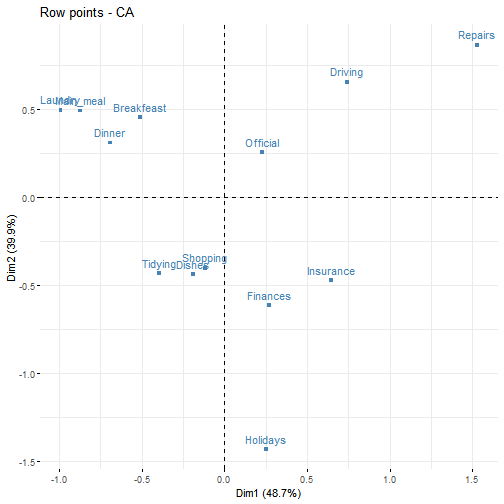

```r
fviz_ca_row(vis_ca, col.row="steelblue", shape.row = 15)
```

It shows the relationship between row points

- Rows with similar profile are grouped together
- Negatively correlated rows are positioned on the opposites sides of the plot origin (opposed quadrants)
- The distance between row points and the origin measures the quality of the row points on the factor map.

### 5m. Assess Cos2

Assess displayed points in two dimension visualization

```r
# Quality of representation of rows
row$cos2
```

```
                Dim 1      Dim 2       Dim 3
Laundry    0.73998741 0.18455213 0.075460467
Main_meal  0.74160285 0.23235928 0.026037873
Dinner     0.77664011 0.15370323 0.069656660
Breakfeast 0.50494329 0.40023001 0.094826699
Tidying    0.43981243 0.53501508 0.025172490
Dishes     0.11811778 0.64615253 0.235729693
Shopping   0.06365362 0.74765514 0.188691242
Official   0.05304464 0.06642648 0.880528877
Driving    0.43201860 0.33522911 0.232752289
Finances   0.16067678 0.83666958 0.002653634
Insurance  0.57601197 0.30880208 0.115185951
Repairs    0.70673575 0.22587147 0.067392778
Holidays   0.02979239 0.96235977 0.007847841
```

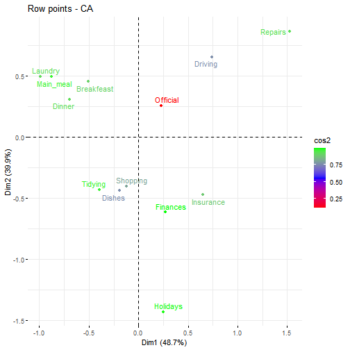

```r
fviz_ca_row(vis_ca, col.row = "cos2",
            gradient.cols = c("red","blue","green"),
            repel = TRUE)
```

The cos2 mesures the degree of association between rows/columns and a particular axis. The values of the cos2 comprised between 0 and 1. the sum of the cost2 for rows on all the CA dimensions is equal to 1. If a row item is well represented by two dimensions, the sum of the cos2 is closed to 1, but for some row items, more than 2 dimentions are required to perfectly represent the data.

Here, as we can see, official has a low score of cos2, this means we need to add another dimensions to increase the degree of associations.

### 5n. Assess Contribution

Inspect the contribution of rows (in %) to the definition of the dimensions

```r
# Contributions to the principal components
head(row$contrib)
```

```
                Dim 1    Dim 2    Dim 3
Laundry    18.2867003 5.563891 7.968424
Main_meal  12.3888433 4.735523 1.858689
Dinner      5.4713982 1.321022 2.096926
Breakfeast  3.8249284 3.698613 3.069399
Tidying     1.9983518 2.965644 0.488734
Dishes      0.4261663 2.844117 3.634294
```

The row variables with larger value, contribute the most to the definition of the dimensions

### Notes:

- Rows that contribute the most to Dim.1 and Dim.2 are the most important in explaining the variability in the data set.
- Rows that do not contribute much to any dimension or that contribute to the last dimensions are less important.

### Show top 10 rows contributing to the dimensions:

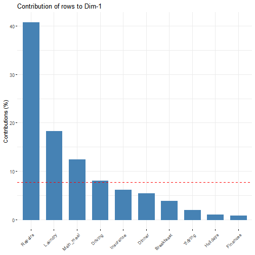

```r
# Contributions of rows to dimension 1
fviz_contrib(vis_ca, choice="row", axes=1, top = 10)
```

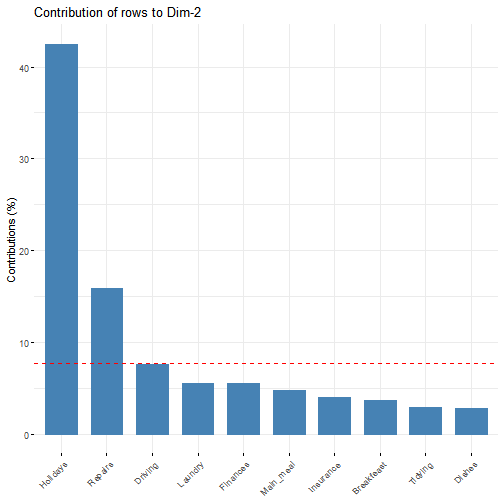

```r
# Contributions of rows to dimension 2
fviz_contrib(vis_ca, choice="row", axes=2, top = 10)
```

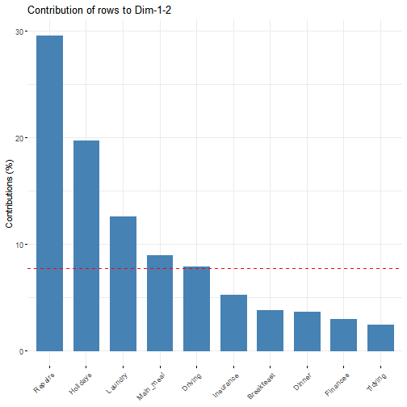

```r
# Total contribution to dimension 1 and 2
fviz_contrib(vis_ca, choice = "row", axes = 1:2, top = 10)
```

The red line indicates expected average value if the contributions were uniform. The calculation based from expected contribution value, under null hypotheses.

### Indicating most important row based on scatter plot:

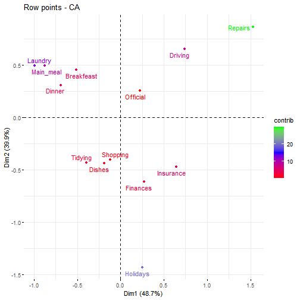

```r
fviz_ca_row(vis_ca, col.row="contrib",
            gradient.cols = c("red","blue","green"),
            repel = TRUE)
```

### 5o. Graph of Column Variables

Determine which column variables contribute the most in the definition of the different dimensions retained in the model.

```r
col = get_ca_col(vis_ca)
col
```

```
Correspondence Analysis - Results for columns
 ===================================================
  Name       Description
1 "$coord"   "Coordinates for the columns"
2 "$cos2"    "Cos2 for the columns"
3 "$contrib" "contributions of the columns"
4 "$inertia" "Inertia of the columns"
```